# Putting It All Together: Advanced Plotting

Introduction to R For Biologists and Bioinformatics

Author

Affiliation

Dr Stevie Pederson

Black Ochre Data Labs  
Telethon Kids Institute

Published

September 17, 2023

# Using the Complete Tidyverse

## Using the Tidyverse

We’ve already learned a huge amount:

1. Importing Data using `readr`
2. Making plots with `ggplot2`
3. Working with vectors and logical tests
4. Using `dplyr` with spreadsheet-like data
5. Joining functions together with `|>`
- Next we’ll:
  - Use everything to make more detailed figures
  - Perform a few analyses
  - Utilise some features of `tidyr`

## Section Setup

1. Clear your `R` Environment
2. Start a new `R` script: `AdvancedPlotting.R`
3. Load the `tidyverse`
4. Define a default `ggplot2` theme
5. Import Transport

```r
library(tidyverse)
theme_set(theme_bw())
cols <- c(
    "gender", "name", "weight", "height", "method"
)
transport <- "data/transport.csv" |>
    read_csv(
        comment = "#",
        col_names = cols,
        col_types = "-ccnnc"
    ) |>
    mutate(
        gender = case_when(
            gender == "F" ~ "female",
            gender == "M" ~ "male",
            TRUE ~ str_to_lower(gender)
        ),
        gender = as.factor(gender),
        method = factor(
            method,
            levels = c("car", "bike")
        ),
        BMI = weight / (0.01 * height) ^ 2
    )
```

## Section Outline

- Using the pipe to create plots
- Customising plots in detail
- Reshaping data using `tidyr`

# Visualising Data

## Visualising Our Data

- What might we like to show?
  - Relationship between weight & height?
  - Association with transportation method
  - Distributions of BMI?

## A Simple X-Y Plot

- When plotting, we can simply pipe the data into `ggplot`

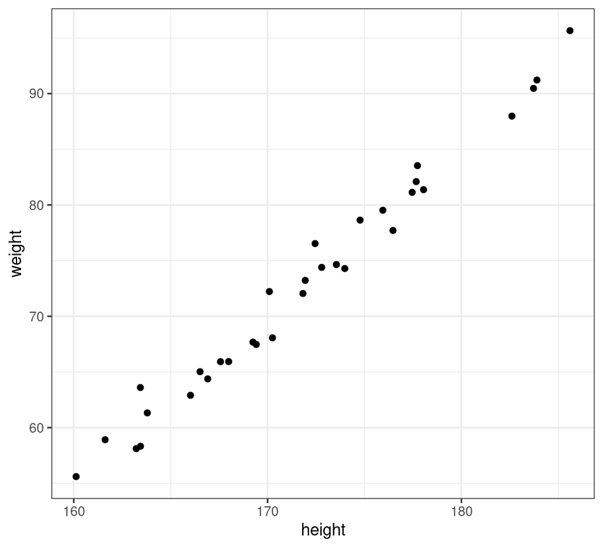

```r
transport |>
    ggplot(aes(height, weight)) +
    geom_point()
```

## Adding Lines of Best Fit

- Sometimes a regression line can be informative
  - `geom_smooth()` guesses the best line
  - `method = 'loess'` isn’t that great here

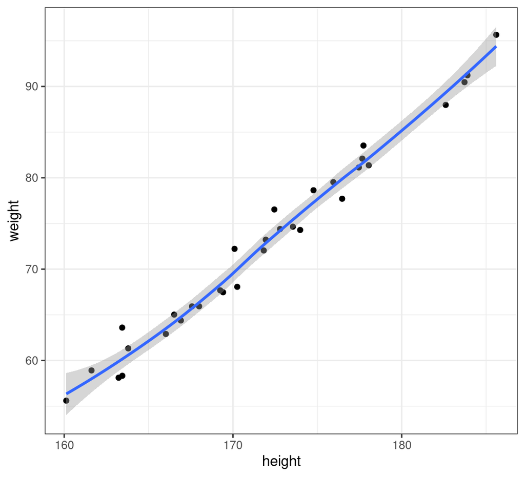

```r
transport |>
    ggplot(aes(height, weight)) +
    geom_point() +
    geom_smooth()
```

## Adding Regresion Lines

- We can choose a linear regression line: `method = "lm"`
  - We fit linear regression in `R` using the function `lm()`
  - Hide the standard error of the regression line: `se = FALSE`

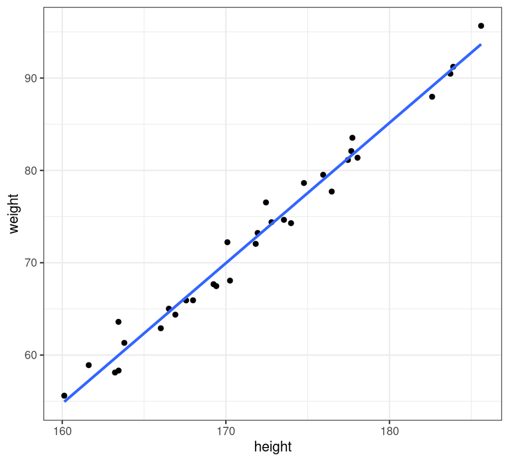

```r
transport |>
    ggplot(aes(height, weight)) +
    geom_point() +
    geom_smooth(method = "lm", se =  FALSE)
```

## Customising Parameters

- We can change the colour of the line: `colour = "black"`
  - Anything set inside `aes()` should be a column in your data
  - Anything set outside of `aes()` should be a fixed-value
  - Can also set `linetype`, `linewidth`, `alpha` etc

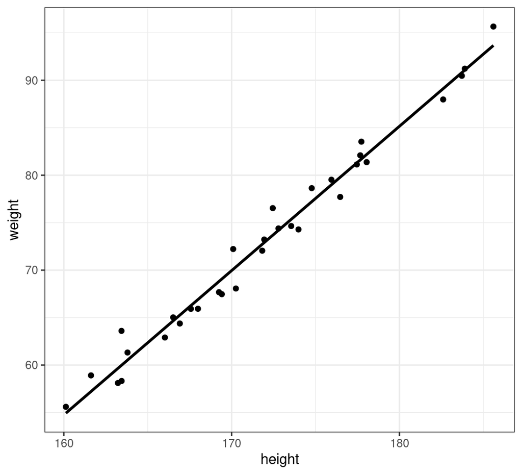

```r
transport |>
    ggplot(aes(height, weight)) +
    geom_point() +
    geom_smooth(
        method = "lm", se =  FALSE,
        colour = "black"
    )
```

## Changing Shapes

- Similarly for the points: `colour = "grey30"`
  - The range of shapes is visible using `?pch`
  - Note that for 21-25 colour is outline, fill is the internal colour

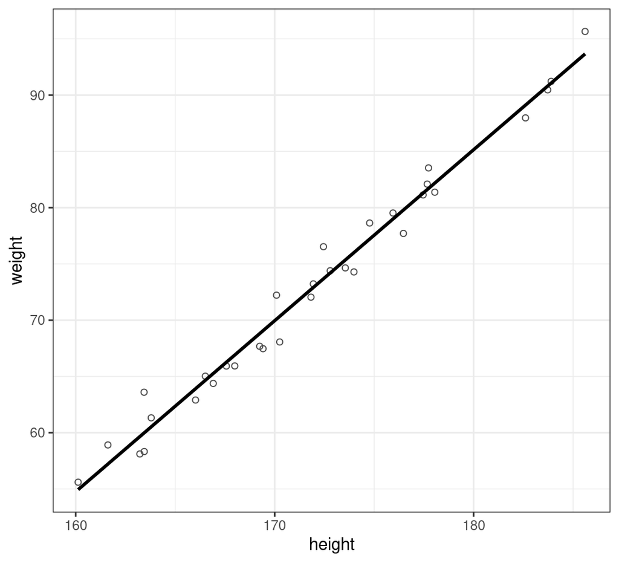

```r
transport |>
    ggplot(aes(height, weight)) +
    geom_point(colour = "grey30", shape = 1) +
    geom_smooth(
        method = "lm", se =  FALSE,
        colour = "black"
    )
```

## Changing Shapes

- We can also set any character to be the point `shape`
  - Additional parameters include `size`, `alpha`

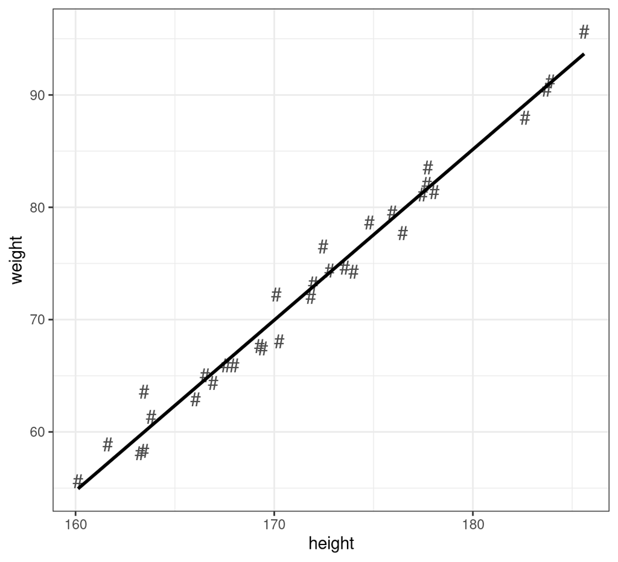

```r
transport |>
    ggplot(aes(height, weight)) +
    geom_point(
        colour = "grey30", shape = "#", size = 4
    ) +
    geom_smooth(
        method = "lm", se =  FALSE,
        colour = "black"
    )
```

Note that size is a relative parameter

## Parameters Inside or Outside `aes()`

- Parameters set outside `aes()` will over-ride anything inside `aes()`
  - We have globally set colour to depend on `gender`
  - This is overridden by both `geom_point()` and `geom_smooth()`

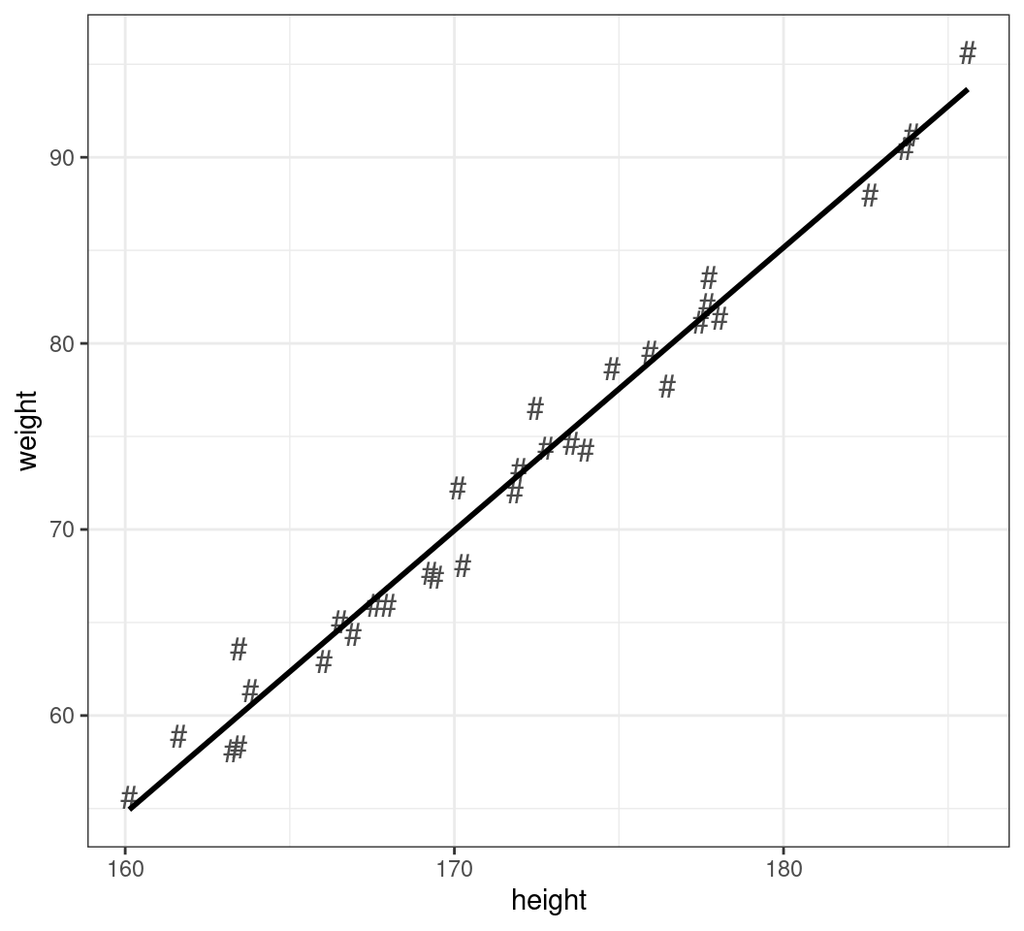

```r
transport |>
    ggplot(
        aes(height, weight, colour = gender)
    ) +
    geom_point(
        colour = "grey30", shape = "#", size = 4
    ) +
    geom_smooth(
        method = "lm", se =  FALSE,
        colour = "black"
    )
```

## Parameters Inside or Outside `aes()`

- Now remove the colour from `geom_point()`
  - Inherits from the `aes()` within `ggplot()`

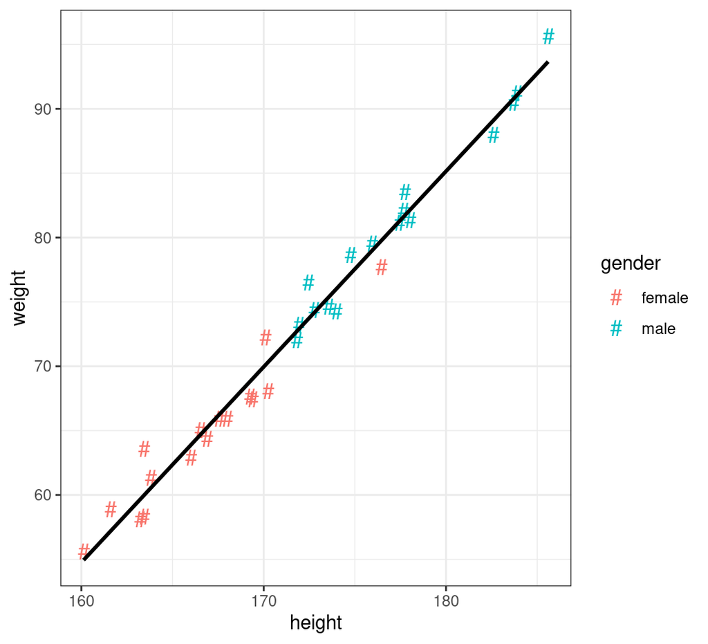

```r
transport |>
    ggplot(
        aes(height, weight, colour = gender)
    ) +
    geom_point(shape = "#", size = 4) +
    geom_smooth(
        method = "lm", se =  FALSE,
        colour = "black"
    )
```

## Custom Scales

- Providing specific colours can take a vector
  - Can be named for greater control

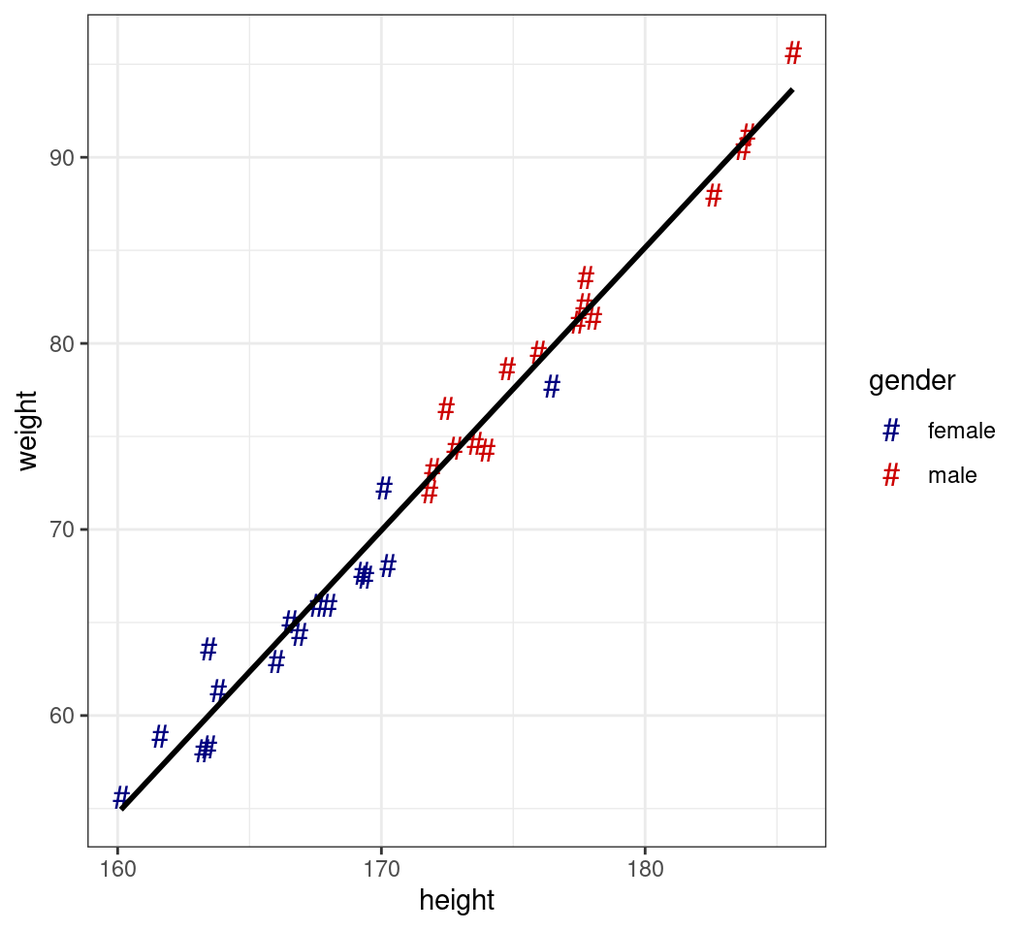

```r
transport |>
    ggplot(
        aes(height, weight, colour = gender)
    ) +
    geom_point(shape = "#", size = 4) +
    geom_smooth(
        method = "lm", se =  FALSE,
        colour = "black"
    ) +
    scale_colour_manual(
        values = c(
            female = "navyblue", male = "red3"
        )
    )
```

## Custom Scales

- Likewise for shapes
  - Values are applied in the same order as the legend

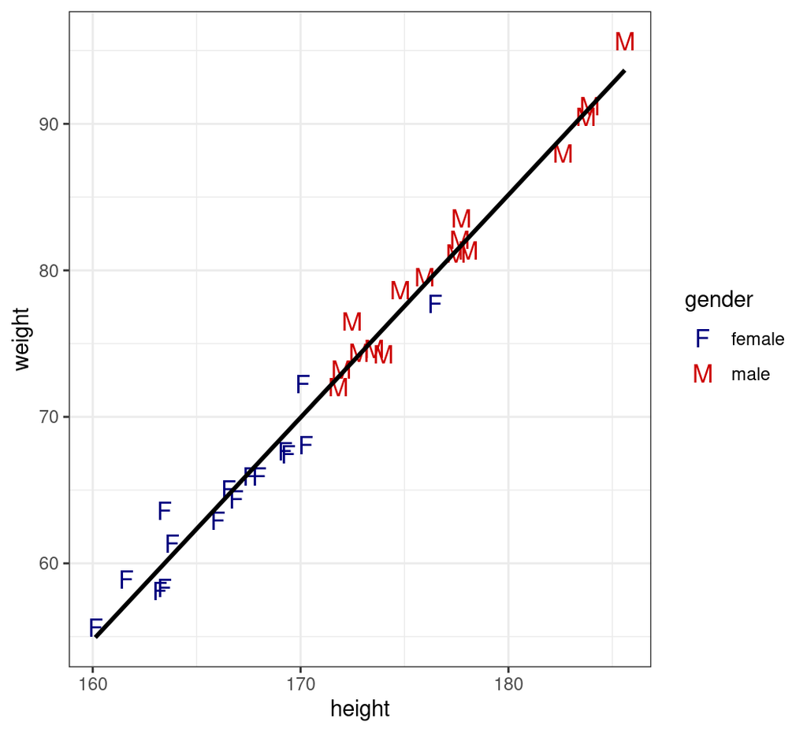

```r
transport |>
    ggplot(
        aes(height, weight, colour = gender)
    ) +
    geom_point(
        aes(shape = gender), size = 4
    ) +
    geom_smooth(
        method = "lm", se =  FALSE,
        colour = "black"
    ) +
    scale_colour_manual(
        values = c(
            female = "navyblue", male = "red3"
        )
    ) +
    scale_shape_manual(
        values = c("F", "M")
    )
```

## Adding Statistics

- Sometimes we might wish to add summary statistics to plots
- We can create on the fly *inside a geom_*

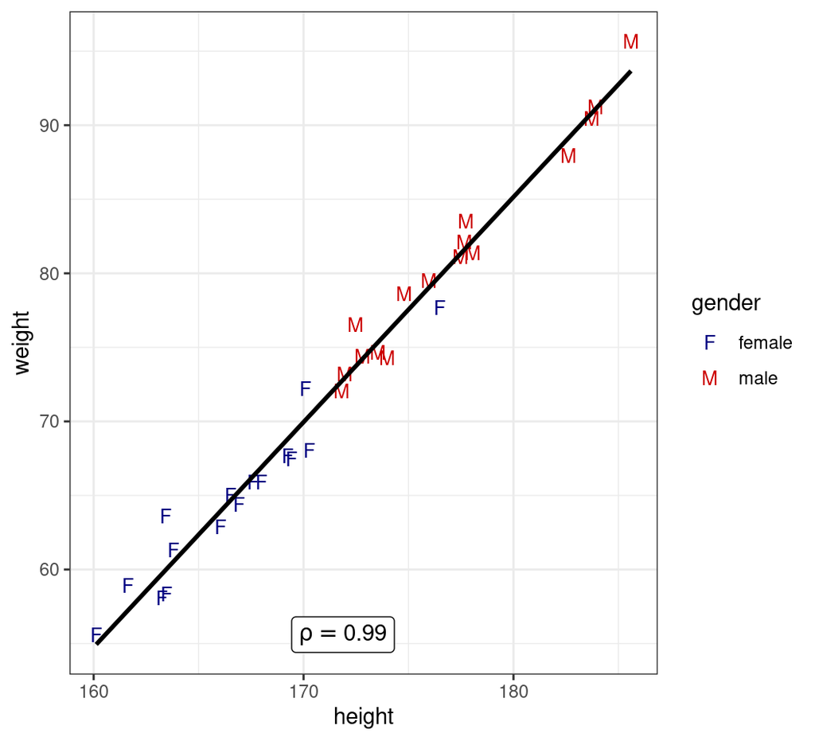

```r
transport |>
    ggplot(aes(height, weight)) +
    geom_point(
        aes(colour = gender, shape = gender),
        size = 3
    ) +
    geom_smooth(
        method = "lm", se =  FALSE,
        colour = "black"
    ) +
    geom_label(
        aes(label = label),
        data = . %>% ## Only the magrittr works here
            summarise(
                cor = cor(weight, height),
                height = mean(height),
                ## Specify a position manually
                # height = 165,
                weight = min(weight),
            )  %>%
            mutate(
                label = paste("rho ==", round(cor, 2))
            ),
        parse = TRUE
    ) +
    scale_colour_manual(
        values = c(
            female = "navyblue", male = "red3"
        )
    ) +
    scale_shape_manual(
        values = c("F", "M")
    )
```

## Using Additional Packages

- There are multiple options for adding other labels

. . .

- Add this to the top of your script  
  $\implies$ Make sure the package is loaded

```r
library(ggpmisc)
```

## Using Additional Packages

- `stat_poly_eq()` can add $R^2$, adjusted $R^2$ or regression equations

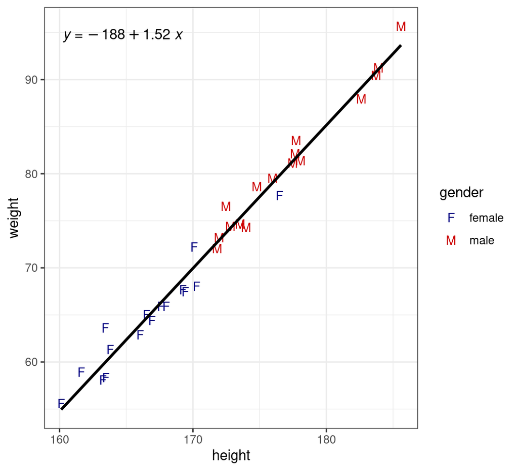

```r
transport |>
    ggplot(aes(height, weight)) +
    geom_point(
        aes(colour = gender, shape = gender),
        size = 3
    ) +
    geom_smooth(
        method = "lm", se =  FALSE,
        colour = "black"
    ) +
    stat_poly_eq(use_label("eq")) +
    scale_colour_manual(
        values = c(
            female = "navyblue", male = "red3"
        )
    ) +
    scale_shape_manual(
        values = c("F", "M")
    )
```

## Multiple Regression Equations

- Combining with facets can provide multiple equations

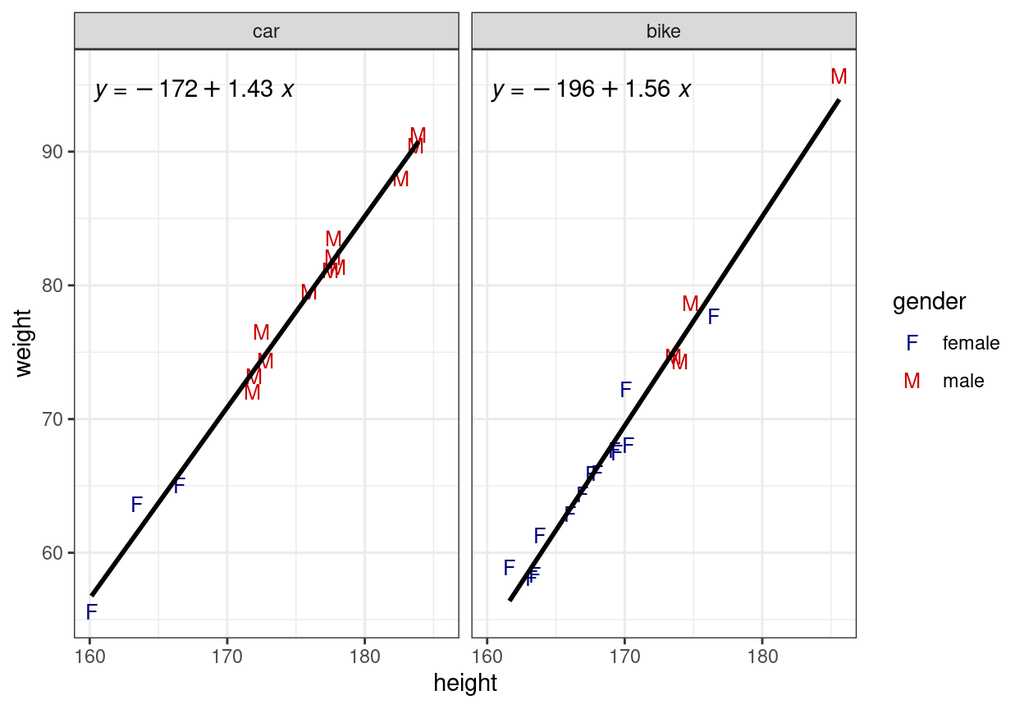

```r
transport |>
    ggplot(aes(height, weight)) +
    geom_point(
        aes(colour = gender, shape = gender),
        size = 3
    ) +
    geom_smooth(
        method = "lm", se =  FALSE,
        colour = "black"
    ) +
    stat_poly_eq(use_label("eq")) +
    facet_wrap(~method) +
    scale_colour_manual(
        values = c(
            female = "navyblue", male = "red3"
        )
    ) +
    scale_shape_manual(
        values = c("F", "M")
    )
```

# Modifying Data Prior To Plotting

## Summary Plots

- So far we’ve just plotted the complete dataset
  - We did use `%>%` inside a `geom_*` to find a correlation…

. . .

- We can also use our `tidyverse` tools to create summaries to plot
  - E.g. Barplots of the mean with error bars

## Summary Plots

- To create a barplot of the mean BMI across all groups
  - Need the mean BMI for each group
  - Also the standard deviation

. . .

```r
transport |>
    summarise(
        mn_bmi = mean(BMI),
        sd_bmi = sd(BMI),
        .by = c(method, gender)
    )
```

## Creating a Barplot

- Now we can create a barplot using `geom_col()`

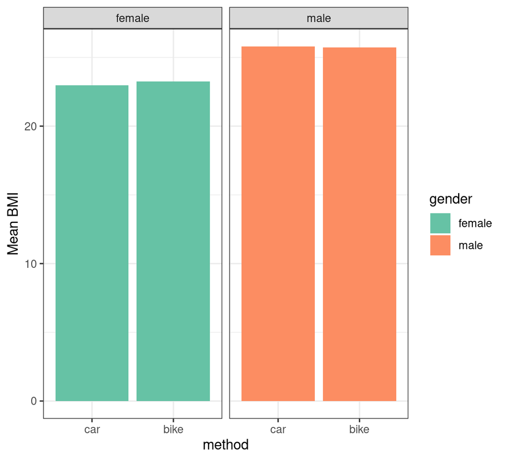

```r
transport |>
    summarise(
        mn_bmi = mean(BMI), sd_bmi = sd(BMI),
        .by = c(method, gender)
    ) |>
    ggplot(aes(method, mn_bmi, fill = gender)) +
    geom_col() +
    facet_wrap(~gender) +
    labs(y = "Mean BMI") +
    scale_fill_brewer(palette = "Set2")
```

## Adding Error Bars

- We add error bars using `geom_errorbar()`

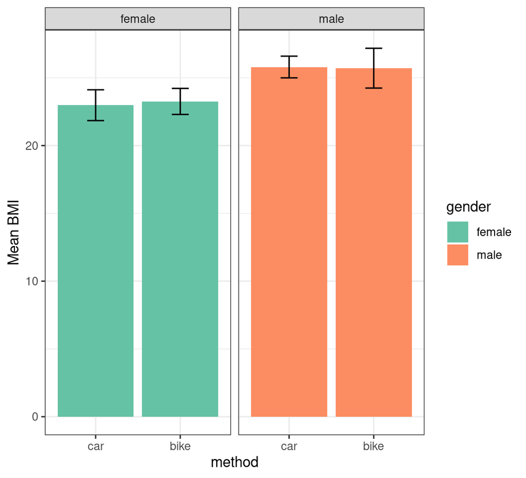

```r
transport |>
    summarise(
        mn_bmi = mean(BMI), sd_bmi = sd(BMI),
        .by = c(method, gender)
    ) |>
    ggplot(aes(method, mn_bmi, fill = gender)) +
    geom_col() +
    geom_errorbar(
        aes(
            ymin = mn_bmi - sd_bmi,
            ymax = mn_bmi + sd_bmi
        ),
        width = 0.2
    ) +
    facet_wrap(~gender) +
    labs(y = "Mean BMI") +
    scale_fill_brewer(palette = "Set2")
```

## Adding Error Bars

- If we choose not to facet it’s much trickier
  - Let’s hide the error bars to see why

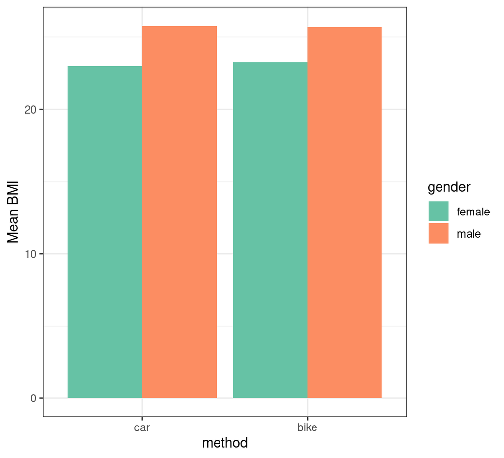

```r
transport |>
    summarise(
        mn_bmi = mean(BMI), sd_bmi = sd(BMI),
        .by = c(method, gender)
    ) |>
    ggplot(aes(method, mn_bmi, fill = gender)) +
    geom_col(position = "dodge") +
    labs(y = "Mean BMI") +
    scale_fill_brewer(palette = "Set2")
```

## Adding Error Bars

- Adding `position = "dodge"` separates the bars horizontally
- What is the x co-ordinate for each bar now?
- What is the width of each bar?

## Plotting with Factors

- Let’s try *coerce* factors to integers

```r
transport |>
    summarise(
        mn_bmi = mean(BMI), sd_bmi = sd(BMI),
        .by = c(method, gender)
    ) |>
    mutate(
        method_int = as.integer(method),
        gender_int = as.integer(gender)
    )
```

```
# A tibble: 4 × 6
  method gender mn_bmi sd_bmi method_int gender_int
  <fct>  <fct>   <dbl>  <dbl>      <int>      <int>
1 car    female   23.0  1.14           1          1
2 bike   female   23.3  0.961          2          1
3 bike   male     25.7  1.47           2          2
4 car    male     25.8  0.799          1          2
```

This can seem weird that we’ve turned a character string into numbers…

## Plotting with Factors

- Each factor level is assigned an integer starting at 1
  - These were how ggplot originally placed the x co-ordinates

. . .

- Can we figure out our x-co-ordinates yet?

. . .

- I guesstimated that each bar had a width of 0.45
  - The centre of each bar is `method_int` $\pm$ 0.225

. . .

- I also wish it was easier
  - Maybe I just haven’t found the right package/function yet

## Plotting with Factors

```r
transport |>
    summarise(
        mn_bmi = mean(BMI), sd_bmi = sd(BMI),
        .by = c(method, gender)
    ) |>
    mutate(
        method_int = as.integer(method),
        gender_int = as.integer(gender),
        x = case_when(
            gender == "female" ~ method_int - 0.225,
            gender == "male" ~ method_int + 0.225,
        )
    )
```

```
# A tibble: 4 × 7
  method gender mn_bmi sd_bmi method_int gender_int     x
  <fct>  <fct>   <dbl>  <dbl>      <int>      <int> <dbl>
1 car    female   23.0  1.14           1          1 0.775
2 bike   female   23.3  0.961          2          1 1.78
3 bike   male     25.7  1.47           2          2 2.22
4 car    male     25.8  0.799          1          2 1.23
```

## Plotting with Factors

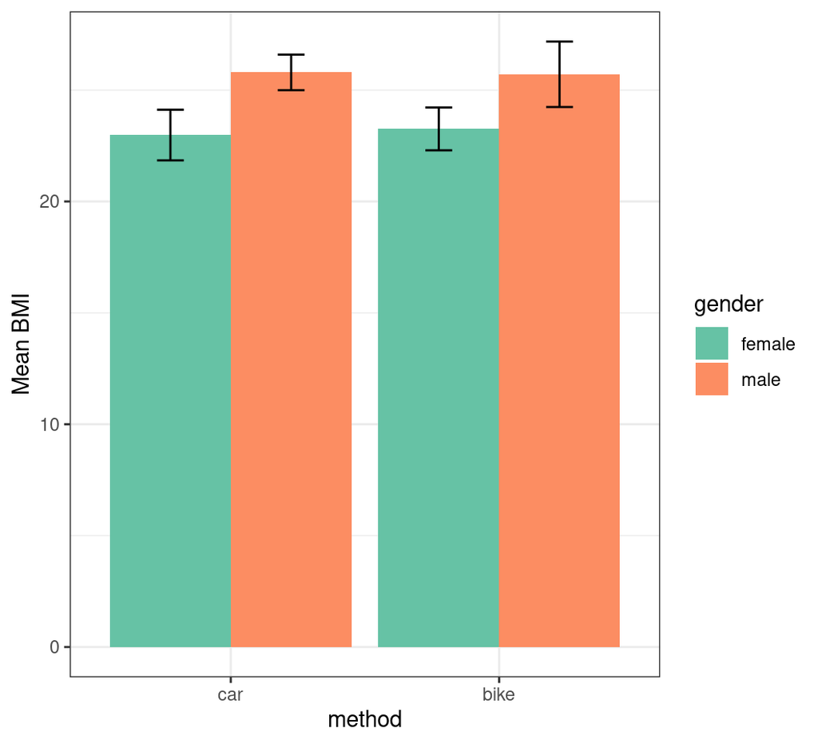

```r
transport |>
    summarise(
        mn_bmi = mean(BMI), sd_bmi = sd(BMI),
        .by = c(method, gender)
    ) |>
    mutate(
        method_int = as.integer(method),
        x = case_when(
            gender == "female" ~ method_int - 0.225,
            gender == "male" ~ method_int + 0.225,
        )
    ) |>
    ggplot(aes(method, mn_bmi, fill = gender)) +
    geom_col(position = "dodge") +
    geom_errorbar(
        aes(
            x = x,
            ymin = mn_bmi - sd_bmi,
            ymax = mn_bmi + sd_bmi
        ),
        width = 0.1
    ) +
    labs(y = "Mean BMI") +
    scale_fill_brewer(palette = "Set2")
```

## Modifying Axes

- That space at the bottom of the y-axis bother me
  - By default axes expand the data by ~5% of the range
- We can control the expansion
  - Using multiplicative scaling (continuous data)
  - Using Additive Scaling (discrete data)
- The relevant function is called `expansion()`
  - Is passed to the `expand` argument inside `scale_x/y_*()`

## Modifying Axes

- We also label them using the `name` argument

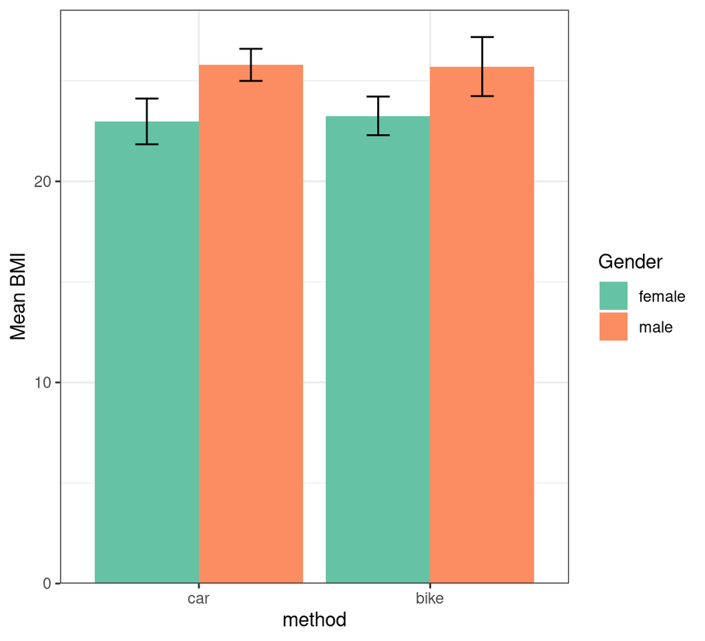

```r
transport |>
    summarise(
        mn_bmi = mean(BMI), sd_bmi = sd(BMI),
        .by = c(method, gender)
    ) |>
    mutate(
        method_int = as.integer(method),
        x = case_when(
            gender == "female" ~ method_int - 0.225,
            gender == "male" ~ method_int + 0.225,
        )
    ) |>
    ggplot(aes(method, mn_bmi, fill = gender)) +
    geom_col(position = "dodge") +
    geom_errorbar(
        aes(
            x = x,
            ymin = mn_bmi - sd_bmi,
            ymax = mn_bmi + sd_bmi
        ), width = 0.1
    ) +
    scale_fill_brewer(
        palette = "Set2", name = "Gender"
    ) +
    scale_y_continuous(
        expand = expansion(c(0, 0.05)),
        name = "Mean BMI"
    )
```

## More Complex Summaries

- So far we only visualised the mean BMI values across the dataset
- Let’s try and repeat for both weight and height on the same figure
  - May not be brilliant in reality

. . .

```r
transport |>
    summarise(
        across(
            ends_with("ght"),
            .fns = c(mn = mean, sd = sd)
        ),
        .by = c(method, gender)
    )
```

```
# A tibble: 4 × 6
  method gender weight_mn weight_sd height_mn height_sd
  <fct>  <fct>      <dbl>     <dbl>     <dbl>     <dbl>
1 car    female      61.4      5.08      163.      3.20
2 bike   female      65.3      5.66      167.      3.95
3 bike   male        80.8     10.1       177.      5.77
4 car    male        81.1      6.44      177.      4.45
```

. . .

*Can we get the means into one column and sd into another?*

## Reshaping Data

- `pivot_longer()` enables shifting from wide to long form
- Choose the columns to run down the page
  - Original column names go into one column
  - All values go into another

. . .

```r
transport |>
    summarise(
        across(
            ends_with("ght"),
            .fns = c(mn = mean, sd = sd)
        ),
        .by = c(method, gender)
    ) |>
    pivot_longer(cols = contains("_"))
```

```
# A tibble: 16 × 4
   method gender name       value
   <fct>  <fct>  <chr>      <dbl>
 1 car    female weight_mn  61.4
 2 car    female weight_sd   5.08
 3 car    female height_mn 163.
 4 car    female height_sd   3.20
 5 bike   female weight_mn  65.3
 6 bike   female weight_sd   5.66
 7 bike   female height_mn 167.
 8 bike   female height_sd   3.95
 9 bike   male   weight_mn  80.8
10 bike   male   weight_sd  10.1
11 bike   male   height_mn 177.
12 bike   male   height_sd   5.77
13 car    male   weight_mn  81.1
14 car    male   weight_sd   6.44
15 car    male   height_mn 177.
16 car    male   height_sd   4.45
```

## Reshaping Data

- We can now `separate()` the values in `name`
  - `into = c("stat", "type")` defines the new column names

```r
transport |>
    summarise(
        across(
            ends_with("ght"),
            .fns = c(mn = mean, sd = sd)
        ),
        .by = c(method, gender)
    ) |>
    pivot_longer(cols = contains("_")) |>
    separate(
        name, into = c("stat", "type"),
        sep = "_"
    )
```

```
# A tibble: 16 × 5
   method gender stat   type   value
   <fct>  <fct>  <chr>  <chr>  <dbl>
 1 car    female weight mn     61.4
 2 car    female weight sd      5.08
 3 car    female height mn    163.
 4 car    female height sd      3.20
 5 bike   female weight mn     65.3
 6 bike   female weight sd      5.66
 7 bike   female height mn    167.
 8 bike   female height sd      3.95
 9 bike   male   weight mn     80.8
10 bike   male   weight sd     10.1
11 bike   male   height mn    177.
12 bike   male   height sd      5.77
13 car    male   weight mn     81.1
14 car    male   weight sd      6.44
15 car    male   height mn    177.
16 car    male   height sd      4.45
```

## Reshaping Data

- The opposite of `pivot_longer()` is `pivot_wider()`

```r
transport |>
    summarise(
        across(
            ends_with("ght"),
            .fns = c(mn = mean, sd = sd)
        ),
        .by = c(method, gender)
    ) |>
    pivot_longer(cols = contains("_")) |>
    separate(
        name, into = c("stat", "type"),
        sep = "_"
    ) |>
    pivot_wider(
        names_from = "type",
        values_from = "value"
    )
```

```
# A tibble: 8 × 5
  method gender stat      mn    sd
  <fct>  <fct>  <chr>  <dbl> <dbl>
1 car    female weight  61.4  5.08
2 car    female height 163.   3.20
3 bike   female weight  65.3  5.66
4 bike   female height 167.   3.95
5 bike   male   weight  80.8 10.1
6 bike   male   height 177.   5.77
7 car    male   weight  81.1  6.44
8 car    male   height 177.   4.45
```

. . .

*Now we have something we can use for barplots with errorbars*

## Reshaping Data

- For the sake of brevity going forward, save that as `summ_df`

```r
summ_df <- transport |>
    summarise(
        across(
            ends_with("ght"),
            .fns = c(mn = mean, sd = sd)
        ),
        .by = c(method, gender)
    ) |>
    pivot_longer(cols = contains("_")) |>
    separate(
        name, into = c("stat", "type"),
        sep = "_"
    ) |>
    pivot_wider(
        names_from = "type",
        values_from = "value"
    )
```

## Plotting Multiple Summaries

- Hide the y-axis name using `name = c()`

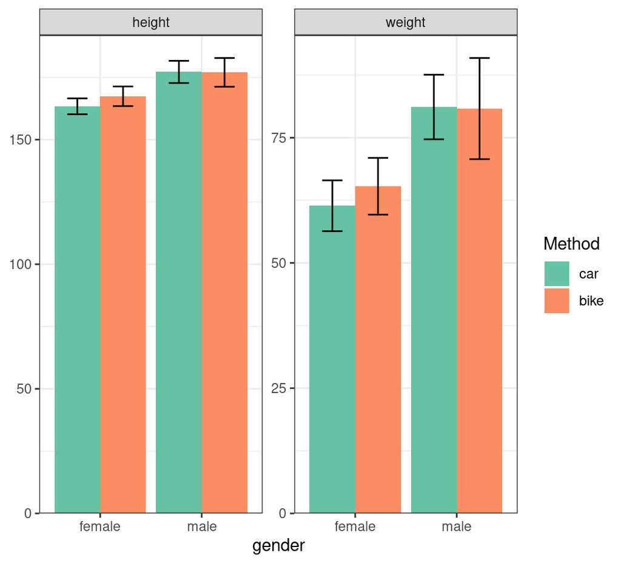

```r
summ_df |>
    mutate(
        gender_int = as.numeric(gender),
        x_bar = case_when(
            method == "car" ~ gender_int - 0.225,
            method == "bike" ~ gender_int + 0.225
        )
    ) |>
    ggplot(aes(gender, mn, fill = method)) +
    geom_col(position = "dodge") +
    geom_errorbar(
        aes(
            x = x_bar,
            ymin = mn - sd, ymax = mn + sd
        ),
        width = 0.2
    )  +
    facet_wrap(~stat, scales = "free_y") +
    scale_fill_brewer(
        palette = "Set2", name = "Method"
    ) +
    scale_y_continuous(
        expand = expansion(c(0, 0.05)),
        name = c()
    )
```

## Plotting Multiple Summaries

- Add the units to the facet names

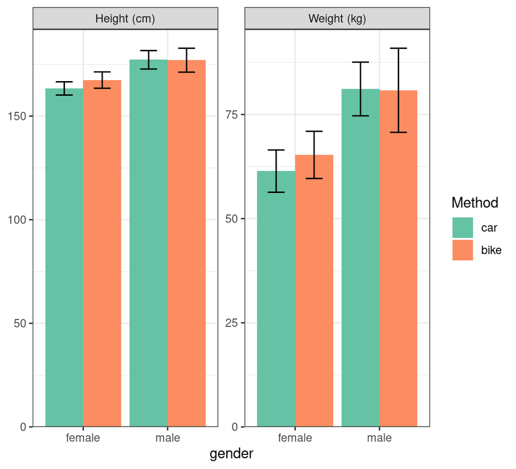

```r
summ_df |>
    mutate(
        gender_int = as.numeric(gender),
        x_bar = case_when(
            method == "car" ~ gender_int - 0.225,
            method == "bike" ~ gender_int + 0.225
        ),
        stat = stat |>
            str_replace("height", "Height (cm)") |>
            str_replace("weight", "Weight (kg)")
    ) |>
    ggplot(aes(gender, mn, fill = method)) +
    geom_col(position = "dodge") +
    geom_errorbar(
        aes(
            x = x_bar,
            ymin = mn - sd, ymax = mn + sd
        ),
        width = 0.2
    )  +
    facet_wrap(~stat, scales = "free_y") +
    scale_fill_brewer(
        palette = "Set2", name = "Method"
    ) +
    scale_y_continuous(
        expand = expansion(c(0, 0.05)), name = c()
    )
```

# Themes

## Using Themes

- The overall plot appearance can be set using `theme()`
- A bit overwhelming, but very customisable
- Let’s save our existing plot a `p`
  - Can be drawn again at anytime by entering `p`
  - Can still be modified on *on-the-fly*

```r
p <- summ_df |>
    mutate(
        gender_int = as.numeric(gender),
        x_bar = case_when(
            method == "car" ~ gender_int - 0.225,
            method == "bike" ~ gender_int + 0.225
        ),
        stat = stat |>
            str_replace("height", "Height (cm)") |>
            str_replace("weight", "Weight (kg)")
    ) |>
    ggplot(aes(gender, mn, fill = method)) +
    geom_col(position = "dodge") +
    geom_errorbar(
        aes(
            x = x_bar,
            ymin = mn - sd, ymax = mn + sd
        ),
        width = 0.2
    )  +
    facet_wrap(~stat, scales = "free_y") +
    xlab("Gender") +
    scale_fill_brewer(
        palette = "Set2", name = "Method"
    ) +
    scale_y_continuous(
        expand = expansion(c(0, 0.05)), name = c()
    )
```

## Using Themes

- If we try to add a title, it’s aligned left

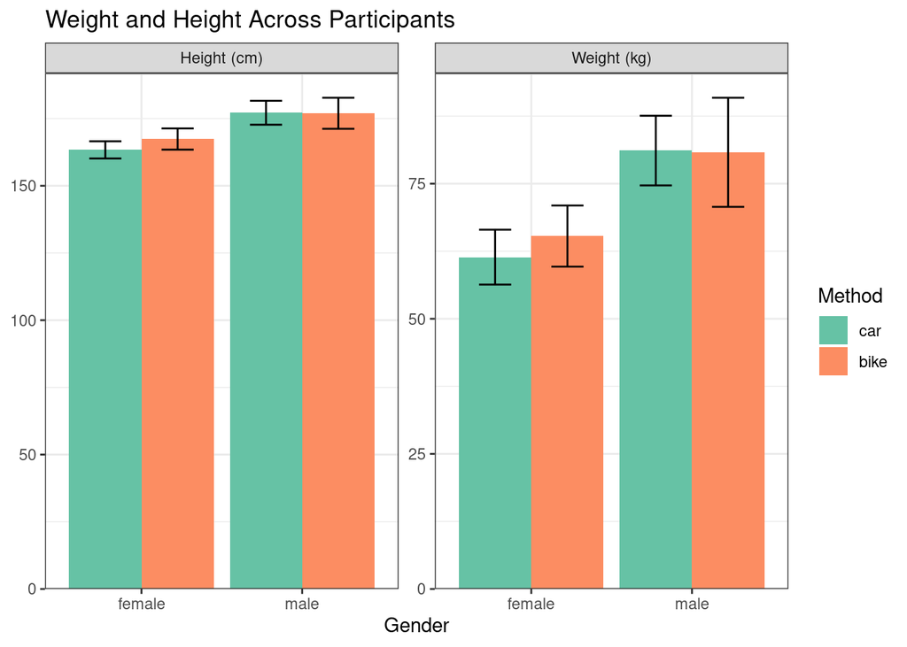

```r
p + ggtitle("Weight and Height Across Participants")
```

## Using Themes

- Most `theme()` elements have their own modification functions
  - text: `element_text()`
  - lines: `element_line()`
  - rectangles: `element_rect()`

. . .

- All can be removed using `element_blank`

. . .

- The plot title needs `element_text()`

## Using Themes

- `hjust` controls the horizontal adjustment
  - `hjust = 0.5` is centre-aligned

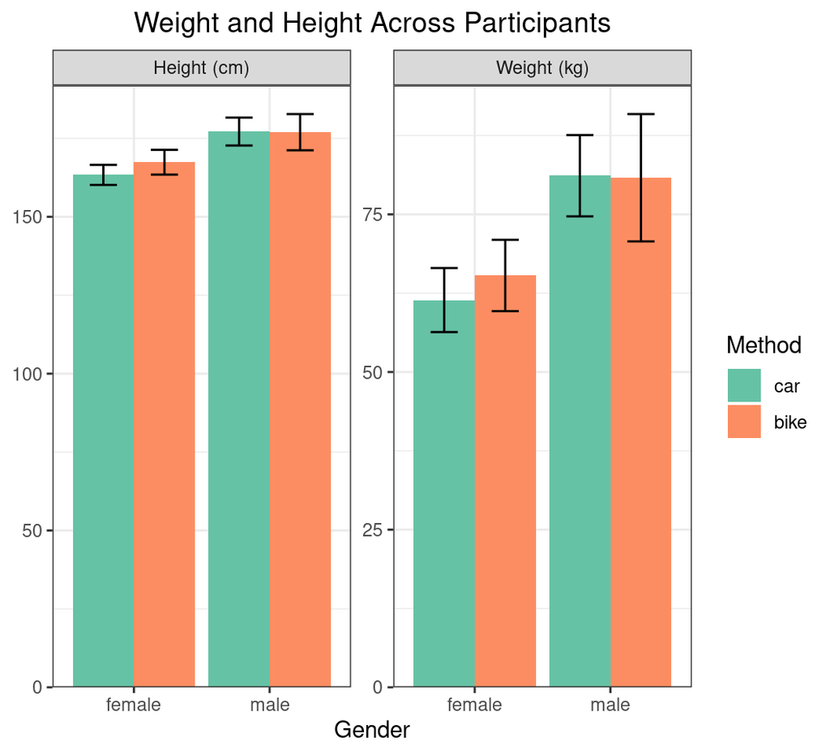

```r
p +
    ggtitle("Weight and Height Across Participants") +
    theme(plot.title = element_text(hjust = 0.5))
```

## Using Themes

- We can resize all primary text

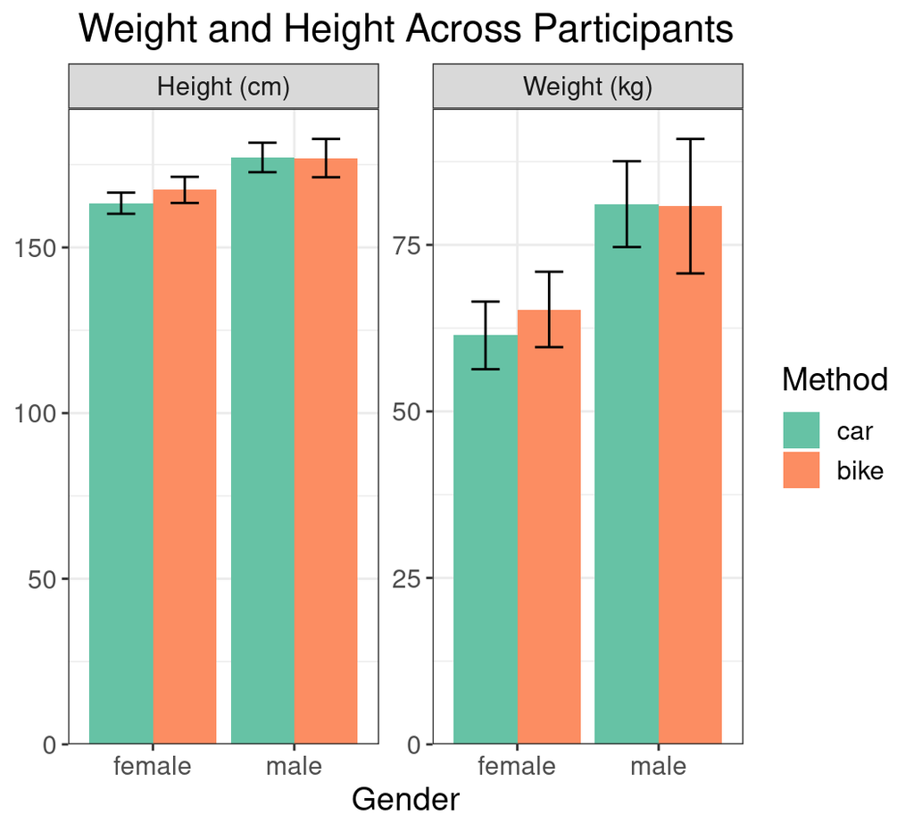

```r
p +
    ggtitle("Weight and Height Across Participants") +
    theme(
        text = element_text(size = 14),
        plot.title = element_text(hjust = 0.5)
    )
```

## Using Themes

- Control legend position
  - Doesn’t need an `element_*()` function

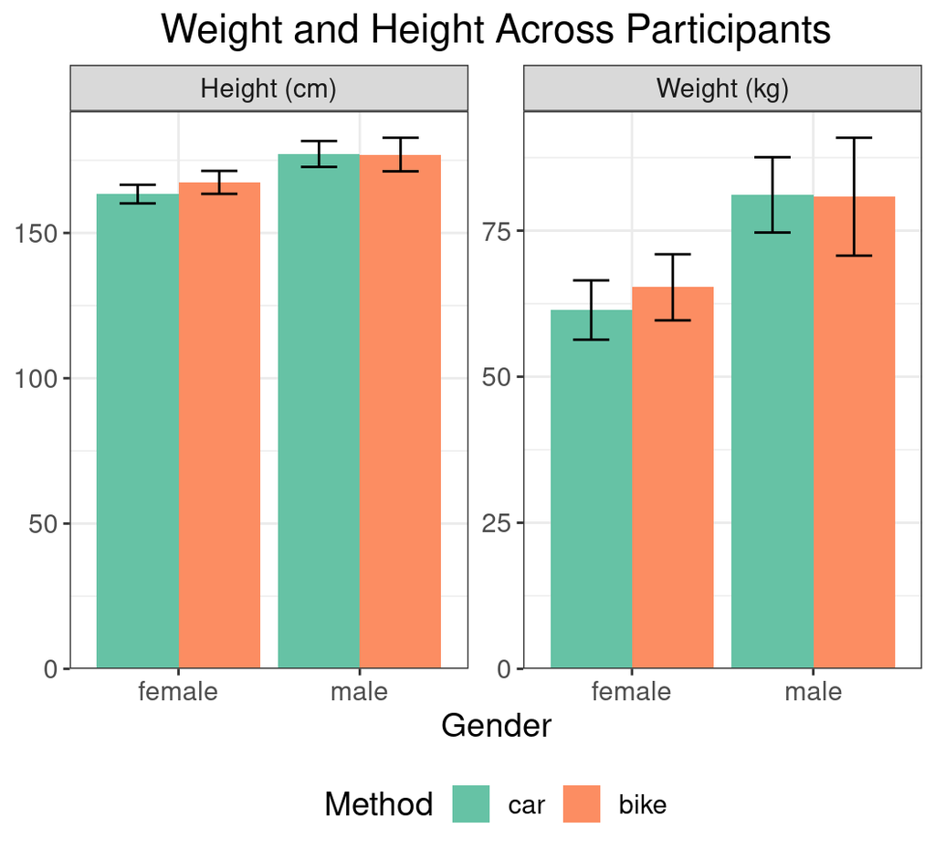

```r
p +
    ggtitle("Weight and Height Across Participants") +
    theme(
        text = element_text(size = 14),
        plot.title = element_text(hjust = 0.5),
        legend.position = "bottom"
    )
```

## Using Themes

- Hide the background grid & rotates x-axis text

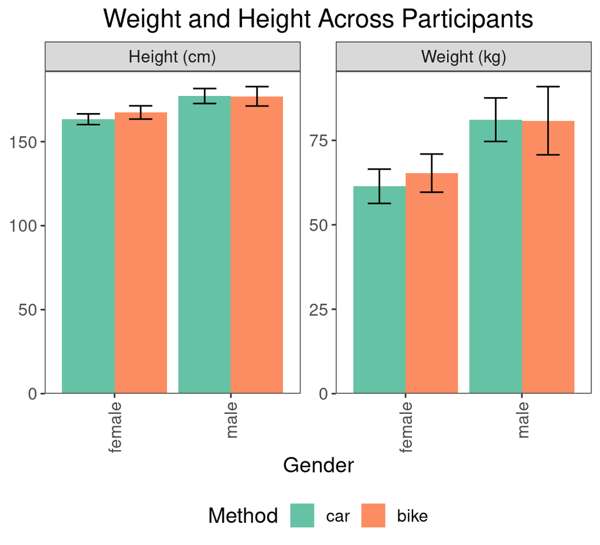

```r
p +
    ggtitle("Weight and Height Across Participants") +
    theme(
        text = element_text(size = 14),
        plot.title = element_text(hjust = 0.5),
        legend.position = "bottom",
        panel.grid = element_blank(),
        axis.text.x = element_text(
            angle = 90, vjust = 0.5, hjust = 1
        )
    )
```

## Exporting Plots

- Making plots in `R` is nice  
  $\implies$ *How do we get them into our paper??!!!*

. . .

- `ggsave()` will save the last plot
  - The file extension will determine the format
  - Can be `png`, `jpg`, `pdf`, `svg`, `tiff` etc
  - `width` & `height` default to inches but can be changed

. . .

- Getting font sizes right can be infuriating
  - Always add the save after you create the plot
  - Open immediately and check the font sizes

## Closing Comments

- Can now (hopefully) make the figures for our next paper
- `ggplot2` is very powerful $\implies$ takes a long time to master
- Getting data structured correctly is an important part

. . .

- Note that once we loaded data $\implies$ never modified

. . .

- We saved four objects
  - `cols`, `transport`, `summ_df`, `p`
  - The last two were only to fit the code on slides

. . .

- This keeps a clean workspace
  - No need for `transport`, `transport1`, `transport1_mod` etc
  - Very beneficial for reproducibility